# IntegrationHeatmapMaker

2023-03-16

## Load libraries and paths

Load `IntegrationFeatureHeatmap` and `dplyr`. Make sure you have downloaded all data from `/data/IntegrationFeatureHeatmap/data` to a local direcotry.

```r
# clear workspace
rm(list=ls())
options(scipen = 999)

# load libraries
library(IntegrationFeatureHeatmap)
library(dplyr)
# download the provided data from agmcfarland/IntegrationFeatureHeatmap/data to a local directory
provided_data <- '/data/IntegrationFeatureHeatmap/data'
```

## Format integration site table

Read in a dataframe of integration sites in the format outputted by AAVengeR.

```r
# read in testset.csv, which contains an example AAVengeR integration sites dataframe
aavenger_sites_raw <- read.csv(file.path(provided_data,'testset.csv'))

print(head(aavenger_sites_raw))
```

```
##     trial  subject  sample refGenome            posid UMIs sonicLengths
## 1 testset subject1 sample1      hg38 chr16-67665165.1   10           10
## 2 testset subject1 sample1      hg38 chr3-193855322.1   10           10
## 3 testset subject1 sample1      hg38  chr2-48952285.1   10           10
## 4 testset subject1 sample1      hg38 chr16-31625838.1   10           10
## 5 testset subject1 sample1      hg38 chr16-20894346.1   10           10
## 6 testset subject1 sample1      hg38  chrX-27657690.1   10           10
##   nRepsObs flags vectorFastaFile rep1.UMIs rep1.sonicLengths rep1.reads
## 1       10    NA    random.fasta        10                10         10
## 2       10    NA    random.fasta        10                10         10
## 3       10    NA    random.fasta        10                10         10
## 4       10    NA    random.fasta        10                10         10
## 5       10    NA    random.fasta        10                10         10
## 6       10    NA    random.fasta        10                10         10
##   rep1.repLeaderSeq maxLeaderSeqDist
## 1          ACTGACTG               10
## 2          ACTGACTG               10
## 3          ACTGACTG               10
## 4          ACTGACTG               10
## 5          ACTGACTG               10
## 6          ACTGACTG               10
```

```r
# format dataframe object to be useable by IntegrationFeatureHeatmap
aavenger_sites <- IntegrationFeatureHeatmap::format_aavenger_sites(
  aavenger_sites_df = aavenger_sites_raw
)

print(head(aavenger_sites))
```

```
##   seqname     start       end width strand       mid      type
## 1   chr16  67665165  67665165     1      *  67665165 insertion
## 2    chr3 193855322 193855322     1      * 193855322 insertion
## 3    chr2  48952285  48952285     1      *  48952285 insertion
## 4   chr16  31625838  31625838     1      *  31625838 insertion
## 5   chr16  20894346  20894346     1      *  20894346 insertion
## 6    chrX  27657690  27657690     1      *  27657690 insertion
##              heatmap_group
## 1 testset_subject1_sample1
## 2 testset_subject1_sample1
## 3 testset_subject1_sample1
## 4 testset_subject1_sample1
## 5 testset_subject1_sample1
## 6 testset_subject1_sample1
```

## Get chromosome lengths

Read in the genomic fasta file that will be used for random sampling.

Normally the genomic fasta would be read in using ShortRead::readFasta(). However, this uses a lot of space. A pre-made chromosome_lengths file is used here for convenience. The hashed out examples show how the genomic fasta would be read in and converted to a chromosome_lengths dataframe.

```r
# genome_fasta <- ShortRead::readFasta(file.path('/home/ubuntu/temp_data/data','hg38.fa.gz')) # example
# chromosome_lengths <- IntegrationFeatureHeatmap::fasta_to_chromosome_lengths(genome_fasta) # example
chromosome_lengths <- read.csv(file.path(provided_data,'testset_chromosome_lengths.csv'))

print(head(chromosome_lengths))
```

```
##   seqname chr_length
## 1    chr1  248956422
## 2    chr2  242193529
## 3    chr3  198295559
## 4    chr4  190214555
## 5    chr5  181538259
## 6    chr6  170805979
```

## Make random-matched dataframes

Each unique `heatmap_group` in `aavenger_sites` is its own dataframe. Each unique `heatmap_group` dataframe will have a random match dataframe with `match_row_number_modifier` times the rows, each with a randomly sampled position from the provided genomic fasta in `chromosome_lengths`.

```r
# generate random-matched dataframes
random_match_df <- IntegrationFeatureHeatmap::aavenger_sites_random_match(
  aavenger_sites = aavenger_sites,
  chromosome_lengths = chromosome_lengths,
  random_seed_value = 10,
  match_row_number_modifier = 3
  )

print(head(random_match_df))
```

```
##   seqname     start       end width strand       mid  type
## 1    chr1 220142461 220142461     1      * 220142461 match
## 2    chr1  79946126  79946126     1      *  79946126 match
## 3    chr1  22034736  22034736     1      *  22034736 match
## 4    chr1 119091188 119091188     1      * 119091188 match
## 5    chr1  85953577  85953577     1      *  85953577 match
## 6    chr1 140936210 140936210     1      * 140936210 match
##              heatmap_group
## 1 testset_subject1_sample1
## 2 testset_subject1_sample1
## 3 testset_subject1_sample1
## 4 testset_subject1_sample1
## 5 testset_subject1_sample1
## 6 testset_subject1_sample1
```

## Combine original integration sites and random match integration sites

Make a long dataframe that is the original aavenger_sites on top of the random_match_df sites.

```r
# combine random match and experimental dataframes
combined_df <- rbind(aavenger_sites, random_match_df)
```

## Check that each integration dataframe has the correct number of random matches

Number of random matches should equal the size of the integration dataframe * `match_row_number_modifier`.

```r
# count the number of insertion sites and match sites
print(combined_df%>%group_by(heatmap_group, type)%>%summarize(count = n ()))
```

```
## # A tibble: 4 × 3
## # Groups:   heatmap_group [2]
##   heatmap_group            type      count
##   <chr>                    <chr>     <int>
## 1 testset_subject1_sample1 insertion  1000
## 2 testset_subject1_sample1 match      3000
## 3 testset_subject2_sample1 insertion  1000
## 4 testset_subject2_sample1 match      3000
```

## Count overlaps for integration sites and genomic features over multiple genomic windows

Each integration site is checked if it overlaps a genomic feature, with the genomic feature being expanded by different genomic windows.

```r
# get the provided RData and rds feature files into a list
feature_files_to_process <- list.files(provided_data, pattern = "\\.(rds|RData)$", full.names = TRUE)

print(feature_files_to_process)
```

```
## [1] "/data/IntegrationFeatureHeatmap/data/DnaseUwJurkat.rds"
## [2] "/data/IntegrationFeatureHeatmap/data/H3K79me2.RData"
```

```r
# test each integration site for overlap in each feature at each given overlap
combined_overlap_test_results_genomic_ranges <- IntegrationFeatureHeatmap::test_for_overlaps(
  matched_aavenger_sites_df = combined_df,
  list_of_feature_files = feature_files_to_process,
  overlap_ranges_to_test = c(1000, 10000, 1000000)
)
```

```
## [1] "/data/IntegrationFeatureHeatmap/data/DnaseUwJurkat.rds"
## [1] "/data/IntegrationFeatureHeatmap/data/H3K79me2.RData"
```

```r
print(head(combined_overlap_test_results_genomic_ranges))
```

```
##   seqname     start       end width strand       mid      type
## 1   chr16  67665165  67665165     1      *  67665165 insertion
## 2    chr3 193855322 193855322     1      * 193855322 insertion
## 3    chr2  48952285  48952285     1      *  48952285 insertion
## 4   chr16  31625838  31625838     1      *  31625838 insertion
## 5   chr16  20894346  20894346     1      *  20894346 insertion
## 6    chrX  27657690  27657690     1      *  27657690 insertion
##              heatmap_group DnaseUwJurkat.rds.1000 DnaseUwJurkat.rds.10000
## 1 testset_subject1_sample1                      0                      10
## 2 testset_subject1_sample1                      0                       0
## 3 testset_subject1_sample1                      0                       0
## 4 testset_subject1_sample1                      0                       0
## 5 testset_subject1_sample1                      0                       0
## 6 testset_subject1_sample1                      0                       0
##   DnaseUwJurkat.rds.1000000 H3K79me2.RData.1000 H3K79me2.RData.10000
## 1                       217                   1                    2
## 2                       109                   1                   11
## 3                         6                   2                   12
## 4                        85                   2                    3
## 5                        54                   4                    8
## 6                         5                   1                    4
##   H3K79me2.RData.1000000
## 1                    465
## 2                    702
## 3                    686
## 4                    408
## 5                    497
## 6                    390
```

## Use hotROCs to calculate the ROC for each integration site group

`IntegrationFeatureHeatmap` calls on `hotROCs` to calculate the ROC area.

```r
hot_roc_result <- IntegrationFeatureHeatmap::hotroc_compare_insertion_to_match(
  matched_overlap_df = combined_overlap_test_results_genomic_ranges
  )
```

## Inspect the hotROCs output

If the ROC is 1, then counts in the experimental integration site dataframe are greater than the random match. If the ROC is 0, then counts are lower than the random match. If the ROC is 0.5, then counts are equally likely for both experimental integration site dataframe and its random match. [See here for code](https://github.com/BushmanLab/hotROCs) and [here for more details](https://www.ncbi.nlm.nih.gov/pmc/articles/PMC5363318/)

```r
head(IntegrationFeatureHeatmap::format_hot_roc_result(hot_roc_result))
```

```
##              feature_window            heatmap_group   p_value sig_p_value
## 1    DnaseUwJurkat.rds.1000 testset_subject1_sample1 0.9520806
## 2    DnaseUwJurkat.rds.1000 testset_subject2_sample1 0.2511167
## 3   DnaseUwJurkat.rds.10000 testset_subject1_sample1 0.5187580
## 4   DnaseUwJurkat.rds.10000 testset_subject2_sample1 0.2985037
## 5 DnaseUwJurkat.rds.1000000 testset_subject1_sample1 0.1818792
## 6 DnaseUwJurkat.rds.1000000 testset_subject2_sample1 0.1234385
##   ROC_value
## 1 0.5002610
## 2 0.5052647
## 3 0.5056050
## 4 0.5090437
## 5 0.5134732
## 6 0.5155448
```

## Make a heatmap of the ROC data

Convert the hotROCs output into a heatmap. P-values and ROC gradients are displayed.

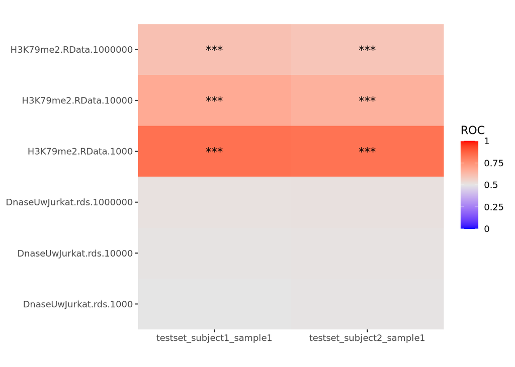

```r
p1 <- IntegrationFeatureHeatmap::roc_to_heatmap(
  hot_roc_result = hot_roc_result
)
print(p1)
```

## Next steps

The heatmap object can be further edited to fit whatever data needs are requird. The ROC areas and p-values are easily accessible using `IntegrationFeatureHeatmap::format_hot_roc_result()`.